Skip to content

# ProductMeasure: Combining Independent True Measures

## Motivation

Sometimes an integrand naturally uses independent components from different true measures. `ProductMeasure` combines those components side by side.

If the marginal dimensions are $d_1, \ldots, d_k$, then the total ProductMeasure dimension is

$$ d = d_1 + \cdots + d_k. $$

A single outer sampler generates points in $[0,1]^d$. `ProductMeasure` splits each point along the final coordinate axis, sends each block to the corresponding marginal transform, and concatenates the transformed blocks.

```python
import matplotlib.pyplot as plt
import numpy as np
import scipy.stats as stats

from qmcpy import (
    DigitalNetB2,
    DummySampler,
    Gaussian,
    GaussianCopula,
    ProductMeasure,
    SciPyWrapper,
    Uniform,
    ZeroInflatedExpUniform,
)
from qmcpy.util import DimensionError, ParameterError

np.set_printoptions(precision=6, suppress=True)
```

import matplotlib.pyplot as plt import numpy as np import scipy.stats as stats from qmcpy import ( DigitalNetB2, DummySampler, Gaussian, GaussianCopula, ProductMeasure, SciPyWrapper, Uniform, ZeroInflatedExpUniform, ) from qmcpy.util import DimensionError, ParameterError np.set_printoptions(precision=6, suppress=True)

## Important note on marginal samplers

QMCPy currently requires every true measure to be constructed with a discrete distribution. In this notebook, `DummySampler` is used only to satisfy that construction requirement for ProductMeasure marginals.

`DummySampler` is a construction placeholder only. Direct sampling from it intentionally raises an error because it cannot generate meaningful QMC points. The only sampler that controls ProductMeasure sampling is the **outer sampler** passed directly to `ProductMeasure`.

Replications also belong to the outer sampler. Marginal `DummySampler` objects do not need matching replications.

### Note on `AcceptanceRejection`

`AcceptanceRejection` is not included as a `ProductMeasure` marginal in this notebook. Unlike the retained marginals, it generates samples directly using a variable number of proposal points and does not currently provide the fixed one-to-one `_transform` required by `ProductMeasure`.

Its samples can be generated separately, but manually joining those samples with another array would not create a `ProductMeasure` sample. It is therefore omitted to avoid suggesting unsupported behavior.

## Example 1: DummySampler verification

**What is being tested?** We call `DummySampler` directly to confirm that it refuses direct sampling, then compare ProductMeasure outputs with identical and different outer sampler seeds.

**Expected result.** Direct calls such as `DummySampler(2)(4)` should raise a clear placeholder error. ProductMeasure sampling should still work because it uses only its own outer sampler.

**Why it matters.** This makes it explicit that marginal `DummySampler` objects satisfy the current true-measure construction API, while the ProductMeasure outer sampler controls actual sample generation.

```python
requested_points = 4
placeholder_message = "construction placeholder"

try:
    DummySampler(2).gen_samples(requested_points)
except ParameterError as error:
    dummy_error = str(error)
else:
    raise AssertionError("DummySampler direct sampling should raise ParameterError")

try:
    DummySampler(2, replications=3).gen_samples(requested_points)
except ParameterError as error:
    dummy_rep_error = str(error)
else:
    raise AssertionError("Replicated DummySampler direct sampling should raise ParameterError")

print("Requested number of points from DummySampler:", requested_points)
print("DummySampler(2) direct sampling result: raised ParameterError")
print("Error message:", dummy_error)
print()
print("DummySampler(2, replications=3) direct sampling result: raised ParameterError")
print("Error message:", dummy_rep_error)
print()

marginals_a = [
    Uniform(DummySampler(1), lower_bound=0.0, upper_bound=2.0),
    Uniform(DummySampler(1), lower_bound=10.0, upper_bound=12.0),
]
marginals_b = [
    Uniform(DummySampler(1), lower_bound=0.0, upper_bound=2.0),
    Uniform(DummySampler(1), lower_bound=10.0, upper_bound=12.0),
]

same_outer_a = ProductMeasure(sampler=DigitalNetB2(2, seed=101), marginals=marginals_a)
same_outer_b = ProductMeasure(sampler=DigitalNetB2(2, seed=101), marginals=marginals_b)
different_outer = ProductMeasure(sampler=DigitalNetB2(2, seed=102), marginals=marginals_b)

samples_same_a = same_outer_a(16)
samples_same_b = same_outer_b(16)
samples_different = different_outer(16)

same_seed_difference = np.max(np.abs(samples_same_a - samples_same_b))
different_seed_difference = np.max(np.abs(samples_same_a - samples_different))

print("ProductMeasure sample shape:", samples_same_a.shape)
print()
print("Same outer sampler seed comparison")
print(f"Maximum absolute difference: {same_seed_difference:.3e}")
print("Expected result: 0.000e+00")
print()
print("Different outer sampler seed comparison")
print(f"Maximum absolute difference: {different_seed_difference:.3e}")
print("Expected result: greater than zero")

assert placeholder_message in dummy_error
assert placeholder_message in dummy_rep_error
assert samples_same_a.shape == (16, 2)
assert same_seed_difference == 0.0
assert different_seed_difference > 0.0
```

requested_points = 4 placeholder_message = "construction placeholder" try: DummySampler(2).gen_samples(requested_points) except ParameterError as error: dummy_error = str(error) else: raise AssertionError("DummySampler direct sampling should raise ParameterError") try: DummySampler(2, replications=3).gen_samples(requested_points) except ParameterError as error: dummy_rep_error = str(error) else: raise AssertionError("Replicated DummySampler direct sampling should raise ParameterError") print("Requested number of points from DummySampler:", requested_points) print("DummySampler(2) direct sampling result: raised ParameterError") print("Error message:", dummy_error) print() print("DummySampler(2, replications=3) direct sampling result: raised ParameterError") print("Error message:", dummy_rep_error) print() marginals_a = [ Uniform(DummySampler(1), lower_bound=0.0, upper_bound=2.0), Uniform(DummySampler(1), lower_bound=10.0, upper_bound=12.0), ] marginals_b = [ Uniform(DummySampler(1), lower_bound=0.0, upper_bound=2.0), Uniform(DummySampler(1), lower_bound=10.0, upper_bound=12.0), ] same_outer_a = ProductMeasure(sampler=DigitalNetB2(2, seed=101), marginals=marginals_a) same_outer_b = ProductMeasure(sampler=DigitalNetB2(2, seed=101), marginals=marginals_b) different_outer = ProductMeasure(sampler=DigitalNetB2(2, seed=102), marginals=marginals_b) samples_same_a = same_outer_a(16) samples_same_b = same_outer_b(16) samples_different = different_outer(16) same_seed_difference = np.max(np.abs(samples_same_a - samples_same_b)) different_seed_difference = np.max(np.abs(samples_same_a - samples_different)) print("ProductMeasure sample shape:", samples_same_a.shape) print() print("Same outer sampler seed comparison") print(f"Maximum absolute difference: {same_seed_difference:.3e}") print("Expected result: 0.000e+00") print() print("Different outer sampler seed comparison") print(f"Maximum absolute difference: {different_seed_difference:.3e}") print("Expected result: greater than zero") assert placeholder_message in dummy_error assert placeholder_message in dummy_rep_error assert samples_same_a.shape == (16, 2) assert same_seed_difference == 0.0 assert different_seed_difference > 0.0

```
Requested number of points from DummySampler: 4
DummySampler(2) direct sampling result: raised ParameterError
Error message: DummySampler is only a construction placeholder for ProductMeasure child true measures and cannot generate samples.

DummySampler(2, replications=3) direct sampling result: raised ParameterError
Error message: DummySampler is only a construction placeholder for ProductMeasure child true measures and cannot generate samples.

ProductMeasure sample shape: (16, 2)

Same outer sampler seed comparison
Maximum absolute difference: 0.000e+00
Expected result: 0.000e+00

Different outer sampler seed comparison
Maximum absolute difference: 1.420e+00
Expected result: greater than zero
```

`DummySampler` is only a construction placeholder and intentionally cannot generate samples directly. The ProductMeasure calls still work because the outer sampler supplies the actual unit-cube points. The identical-output comparison shows that two ProductMeasure objects with the same outer sampler receive the same points, while changing only the outer sampler seed changes the transformed samples.

## Example 2: Replications

**What is being tested?** We use the same two uniform marginals, but the outer sampler now has three randomized replications.

**Expected result.** The output shape should be `(replications, n, total_dimension)`, here `(3, n, 2)`. Each replication should have sample means close to `1` and `11`.

**Why it matters.** This verifies that replications belong to the outer sampler and are preserved by `ProductMeasure` without needing replicated `DummySampler` marginals.

```python
n = 1024
replications = 3
marginals = [
    Uniform(DummySampler(1), lower_bound=0.0, upper_bound=2.0),
    Uniform(DummySampler(1), lower_bound=10.0, upper_bound=12.0),
]
outer_sampler = DigitalNetB2(2, seed=13, replications=replications)
product_measure = ProductMeasure(sampler=outer_sampler, marginals=marginals)

samples = product_measure(n)
expected_shape = (outer_sampler.replications, n, product_measure.d)
replication_means = samples.mean(axis=1)
errors = replication_means - np.array([1.0, 11.0])

print("Number of replications:", outer_sampler.replications)
print("Samples per replication:", n)
print("Total product dimension:", product_measure.d)
print("Expected output shape:", expected_shape)
print("Actual output shape:", samples.shape)
print()
print("Replication    Mean of U(0,2)    Error from 1    Mean of U(10,12)    Error from 11")
for i, (means, errs) in enumerate(zip(replication_means, errors), start=1):
    print(f"{i:>11}    {means[0]:>14.6f}    {errs[0]:>12.3e}    {means[1]:>17.6f}    {errs[1]:>13.3e}")

assert samples.shape == expected_shape
assert np.allclose(replication_means[:, 0], 1.0, atol=0.03)
assert np.allclose(replication_means[:, 1], 11.0, atol=0.03)

x_axis = np.arange(1, outer_sampler.replications + 1)
fig, ax = plt.subplots(figsize=(7.0, 4.8))
ax.plot(x_axis, replication_means[:, 0], marker="o", linewidth=2, label="Observed mean: Uniform(0, 2)")
ax.axhline(1.0, color="C0", linestyle="--", linewidth=1.5, label="Theoretical mean: 1")
ax.plot(x_axis, replication_means[:, 1], marker="s", linewidth=2, label="Observed mean: Uniform(10, 12)")
ax.axhline(11.0, color="C1", linestyle=":", linewidth=1.8, label="Theoretical mean: 11")
ax.set_xticks(x_axis)
ax.set_xlabel("Replication")
ax.set_ylabel("Sample mean")
ax.set_title("Replication-wise Means Compared with Theoretical Means")
ax.legend(loc="best")
plt.tight_layout()
plt.show()
```

n = 1024 replications = 3 marginals = [ Uniform(DummySampler(1), lower_bound=0.0, upper_bound=2.0), Uniform(DummySampler(1), lower_bound=10.0, upper_bound=12.0), ] outer_sampler = DigitalNetB2(2, seed=13, replications=replications) product_measure = ProductMeasure(sampler=outer_sampler, marginals=marginals) samples = product_measure(n) expected_shape = (outer_sampler.replications, n, product_measure.d) replication_means = samples.mean(axis=1) errors = replication_means - np.array([1.0, 11.0]) print("Number of replications:", outer_sampler.replications) print("Samples per replication:", n) print("Total product dimension:", product_measure.d) print("Expected output shape:", expected_shape) print("Actual output shape:", samples.shape) print() print("Replication Mean of U(0,2) Error from 1 Mean of U(10,12) Error from 11") for i, (means, errs) in enumerate(zip(replication_means, errors), start=1): print(f"{i:>11} {means[0]:>14.6f} {errs[0]:>12.3e} {means[1]:>17.6f} {errs[1]:>13.3e}") assert samples.shape == expected_shape assert np.allclose(replication_means[:, 0], 1.0, atol=0.03) assert np.allclose(replication_means[:, 1], 11.0, atol=0.03) x_axis = np.arange(1, outer_sampler.replications + 1) fig, ax = plt.subplots(figsize=(7.0, 4.8)) ax.plot(x_axis, replication_means[:, 0], marker="o", linewidth=2, label="Observed mean: Uniform(0, 2)") ax.axhline(1.0, color="C0", linestyle="--", linewidth=1.5, label="Theoretical mean: 1") ax.plot(x_axis, replication_means[:, 1], marker="s", linewidth=2, label="Observed mean: Uniform(10, 12)") ax.axhline(11.0, color="C1", linestyle=":", linewidth=1.8, label="Theoretical mean: 11") ax.set_xticks(x_axis) ax.set_xlabel("Replication") ax.set_ylabel("Sample mean") ax.set_title("Replication-wise Means Compared with Theoretical Means") ax.legend(loc="best") plt.tight_layout() plt.show()

```
Number of replications: 3
Samples per replication: 1024
Total product dimension: 2
Expected output shape: (3, 1024, 2)
Actual output shape: (3, 1024, 2)

Replication    Mean of U(0,2)    Error from 1    Mean of U(10,12)    Error from 11
          1          1.000000      -1.110e-16            10.999999       -9.537e-07
          2          1.000000       0.000e+00            11.000000        8.882e-15
          3          1.000000       0.000e+00            11.000000       -3.553e-15
```

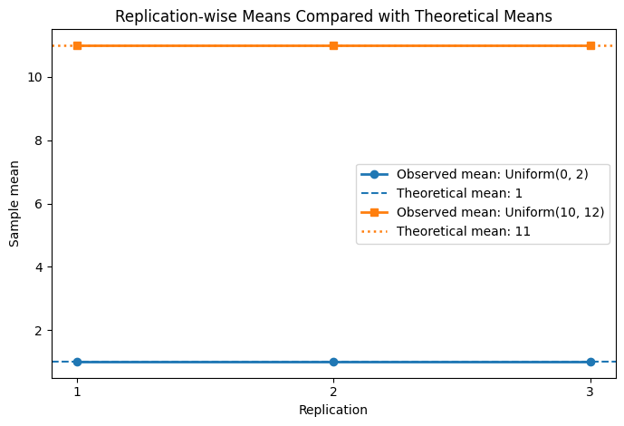

The small differences across replications come from independent randomizations of the outer sampler. The closeness to `1` and `11` confirms that each replication targets the same product distribution.

## Example 3: Multidimensional and zero-inflated marginals

**What is being tested?** We combine a two-dimensional Gaussian marginal with a one-dimensional zero-inflated exponential marginal.

**Expected result.** The total dimension should be `3`. The first two output columns should form the Gaussian block, and the third output column should contain nonnegative zero-inflated values with an observed zero proportion close to `p_zero`.

**Why it matters.** This shows that a ProductMeasure marginal may itself be multidimensional, while another marginal can be mixed/discrete-continuous through its inverse-CDF transform.

`ZeroInflatedExpUniform` supplies a sampling transform but not a density. This example validates the transformed samples and zero mass, not ProductMeasure density weights for that marginal.

```python
n = 2048
p_zero = 0.4
gaussian = Gaussian(
    DummySampler(2),
    mean=[0.0, 0.0],
    covariance=[[1.0, 0.6], [0.6, 1.0]],
)
zero_inflated = ZeroInflatedExpUniform(DummySampler(1), p_zero=p_zero, lam=1.5)
marginals = [gaussian, zero_inflated]
outer_sampler = DigitalNetB2(3, seed=31)
product_measure = ProductMeasure(sampler=outer_sampler, marginals=marginals)

samples = product_measure(n)
gaussian_samples = samples[:, : gaussian.d]
zero_inflated_samples = samples[:, gaussian.d :]
observed_zero_rate = np.mean(zero_inflated_samples[:, 0] == 0.0)
observed_corr = np.corrcoef(gaussian_samples.T)[0, 1]

print("Gaussian marginal dimension:", gaussian.d)
print("Zero-inflated marginal dimension:", zero_inflated.d)
print("Expected total dimension:", gaussian.d + zero_inflated.d)
print("Actual ProductMeasure dimension:", product_measure.d)
print("Full sample shape:", samples.shape)
print("Gaussian block shape:", gaussian_samples.shape)
print("Zero-inflated block shape:", zero_inflated_samples.shape)
print(f"Specified zero probability: {p_zero:.4f}")
print(f"Observed zero proportion: {observed_zero_rate:.4f}")
print(f"Absolute zero-proportion error: {abs(observed_zero_rate - p_zero):.4f}")
print(f"Target Gaussian correlation: 0.6000")
print(f"Observed Gaussian correlation: {observed_corr:.4f}")

assert product_measure.d == gaussian.d + zero_inflated.d
assert samples.shape == (n, 3)
assert gaussian_samples.shape == (n, 2)
assert zero_inflated_samples.shape == (n, 1)
assert np.all(zero_inflated_samples >= 0.0)
assert abs(observed_zero_rate - p_zero) < 0.05

positive_values = zero_inflated_samples[zero_inflated_samples[:, 0] > 0.0, 0]
fig, axes = plt.subplots(1, 2, figsize=(11.5, 4.8))

axes[0].scatter(gaussian_samples[:, 0], gaussian_samples[:, 1], s=10, alpha=0.35, label="Gaussian samples")
axes[0].set_xlabel("Gaussian marginal coordinate 1")
axes[0].set_ylabel("Gaussian marginal coordinate 2")
axes[0].set_title("2D Gaussian Marginal with Positive Correlation")
axes[0].legend(loc="best")

axes[1].bar(["Exact zero", "Positive"], [observed_zero_rate, 1.0 - observed_zero_rate], color=["C3", "C2"], alpha=0.75, label="Observed proportion")
axes[1].axhline(p_zero, color="C3", linestyle="--", linewidth=1.5, label=f"Specified p_zero = {p_zero:.1f}")
axes[1].set_ylim(0, 1)
axes[1].set_ylabel("Proportion")
axes[1].set_title("Zero Mass in the Zero-inflated Marginal")
axes[1].legend(loc="best")

plt.tight_layout()
plt.show()

fig, ax = plt.subplots(figsize=(6.5, 4.5))
ax.hist(positive_values, bins=35, alpha=0.75, color="C2", label="Positive values only")
ax.set_xlabel("Value")
ax.set_ylabel("Count")
ax.set_title("Zero-inflated Exponential Marginal: Positive Tail")
ax.legend(loc="best")
plt.tight_layout()
plt.show()
```

n = 2048 p_zero = 0.4 gaussian = Gaussian( DummySampler(2), mean=[0.0, 0.0], covariance=[[1.0, 0.6], [0.6, 1.0]], ) zero_inflated = ZeroInflatedExpUniform(DummySampler(1), p_zero=p_zero, lam=1.5) marginals = [gaussian, zero_inflated] outer_sampler = DigitalNetB2(3, seed=31) product_measure = ProductMeasure(sampler=outer_sampler, marginals=marginals) samples = product_measure(n) gaussian_samples = samples[:, : gaussian.d] zero_inflated_samples = samples[:, gaussian.d :] observed_zero_rate = np.mean(zero_inflated_samples[:, 0] == 0.0) observed_corr = np.corrcoef(gaussian_samples.T)[0, 1] print("Gaussian marginal dimension:", gaussian.d) print("Zero-inflated marginal dimension:", zero_inflated.d) print("Expected total dimension:", gaussian.d + zero_inflated.d) print("Actual ProductMeasure dimension:", product_measure.d) print("Full sample shape:", samples.shape) print("Gaussian block shape:", gaussian_samples.shape) print("Zero-inflated block shape:", zero_inflated_samples.shape) print(f"Specified zero probability: {p_zero:.4f}") print(f"Observed zero proportion: {observed_zero_rate:.4f}") print(f"Absolute zero-proportion error: {abs(observed_zero_rate - p_zero):.4f}") print(f"Target Gaussian correlation: 0.6000") print(f"Observed Gaussian correlation: {observed_corr:.4f}") assert product_measure.d == gaussian.d + zero_inflated.d assert samples.shape == (n, 3) assert gaussian_samples.shape == (n, 2) assert zero_inflated_samples.shape == (n, 1) assert np.all(zero_inflated_samples >= 0.0) assert abs(observed_zero_rate - p_zero) < 0.05 positive_values = zero_inflated_samples[zero_inflated_samples[:, 0] > 0.0, 0] fig, axes = plt.subplots(1, 2, figsize=(11.5, 4.8)) axes[0].scatter(gaussian_samples[:, 0], gaussian_samples[:, 1], s=10, alpha=0.35, label="Gaussian samples") axes[0].set_xlabel("Gaussian marginal coordinate 1") axes[0].set_ylabel("Gaussian marginal coordinate 2") axes[0].set_title("2D Gaussian Marginal with Positive Correlation") axes[0].legend(loc="best") axes[1].bar(["Exact zero", "Positive"], [observed_zero_rate, 1.0 - observed_zero_rate], color=["C3", "C2"], alpha=0.75, label="Observed proportion") axes[1].axhline(p_zero, color="C3", linestyle="--", linewidth=1.5, label=f"Specified p_zero = {p_zero:.1f}") axes[1].set_ylim(0, 1) axes[1].set_ylabel("Proportion") axes[1].set_title("Zero Mass in the Zero-inflated Marginal") axes[1].legend(loc="best") plt.tight_layout() plt.show() fig, ax = plt.subplots(figsize=(6.5, 4.5)) ax.hist(positive_values, bins=35, alpha=0.75, color="C2", label="Positive values only") ax.set_xlabel("Value") ax.set_ylabel("Count") ax.set_title("Zero-inflated Exponential Marginal: Positive Tail") ax.legend(loc="best") plt.tight_layout() plt.show()

```
Gaussian marginal dimension: 2
Zero-inflated marginal dimension: 1
Expected total dimension: 3
Actual ProductMeasure dimension: 3
Full sample shape: (2048, 3)
Gaussian block shape: (2048, 2)
Zero-inflated block shape: (2048, 1)
Specified zero probability: 0.4000
Observed zero proportion: 0.3999
Absolute zero-proportion error: 0.0001
Target Gaussian correlation: 0.6000
Observed Gaussian correlation: 0.5998
```

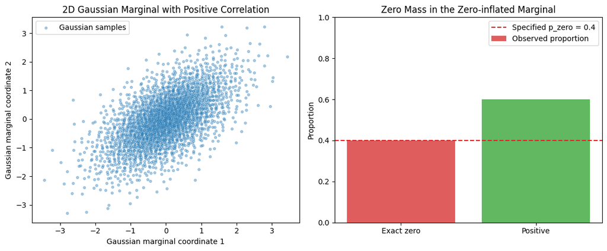

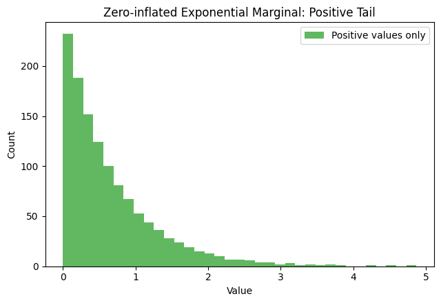

The dimension and block-shape checks show that `ProductMeasure` split the three-dimensional outer samples into a 2D Gaussian block and a 1D zero-inflated block. The zero proportion is close to the specified `p_zero`, and the Gaussian scatter reflects the positive target correlation.

## Example 4: Basic ProductMeasure

**What is being tested?** We combine two one-dimensional marginals: `Uniform(0, 2)` and `Uniform(10, 12)`.

**Expected result.** The output should have shape `(n, 2)`, the first coordinate should stay inside `[0, 2]`, the second coordinate should stay inside `[10, 12]`, and the sample means should be close to the theoretical means `1` and `11`.

**Why it matters.** This is the core ProductMeasure behavior: one two-dimensional outer QMC point is split into two one-dimensional coordinate blocks and transformed by the two marginals.

```python
n = 256
marginals = [
    Uniform(DummySampler(1), lower_bound=0.0, upper_bound=2.0),
    Uniform(DummySampler(1), lower_bound=10.0, upper_bound=12.0),
]
outer_sampler = DigitalNetB2(2, seed=7)
product_measure = ProductMeasure(sampler=outer_sampler, marginals=marginals)

samples = product_measure(n)
expected_shape = (n, 2)
expected_means = np.array([1.0, 11.0])
observed_means = samples.mean(axis=0)

print("Expected sample shape:", expected_shape)
print("Actual sample shape:", samples.shape)
print("ProductMeasure dimension:", product_measure.d)
print()
print("Marginal 1: Uniform(0, 2)")
print(f"  Observed range: [{samples[:, 0].min():.6f}, {samples[:, 0].max():.6f}]")
print(f"  Observed mean: {observed_means[0]:.6f}")
print(f"  Theoretical mean: {expected_means[0]:.6f}")
print(f"  Absolute mean error: {abs(observed_means[0] - expected_means[0]):.3e}")
print()
print("Marginal 2: Uniform(10, 12)")
print(f"  Observed range: [{samples[:, 1].min():.6f}, {samples[:, 1].max():.6f}]")
print(f"  Observed mean: {observed_means[1]:.6f}")
print(f"  Theoretical mean: {expected_means[1]:.6f}")
print(f"  Absolute mean error: {abs(observed_means[1] - expected_means[1]):.3e}")

assert samples.shape == expected_shape
assert np.all((0.0 <= samples[:, 0]) & (samples[:, 0] <= 2.0))
assert np.all((10.0 <= samples[:, 1]) & (samples[:, 1] <= 12.0))

fig, ax = plt.subplots(figsize=(6.5, 5.0))
ax.scatter(samples[:, 0], samples[:, 1], s=18, alpha=0.6, label="ProductMeasure samples")
ax.axvline(expected_means[0], color="C0", linestyle="--", linewidth=1.5, label="Mean of Uniform(0, 2) = 1")
ax.axhline(expected_means[1], color="C1", linestyle="--", linewidth=1.5, label="Mean of Uniform(10, 12) = 11")
ax.plot([0, 2, 2, 0, 0], [10, 10, 12, 12, 10], color="black", linewidth=1.5, label="Expected rectangular support")
ax.set_xlabel("Marginal 1: Uniform(0, 2)")
ax.set_ylabel("Marginal 2: Uniform(10, 12)")
ax.set_title("Samples from the Product of Two Uniform Marginals")
ax.legend(loc="best")
plt.tight_layout()
plt.show()
```

n = 256 marginals = [ Uniform(DummySampler(1), lower_bound=0.0, upper_bound=2.0), Uniform(DummySampler(1), lower_bound=10.0, upper_bound=12.0), ] outer_sampler = DigitalNetB2(2, seed=7) product_measure = ProductMeasure(sampler=outer_sampler, marginals=marginals) samples = product_measure(n) expected_shape = (n, 2) expected_means = np.array([1.0, 11.0]) observed_means = samples.mean(axis=0) print("Expected sample shape:", expected_shape) print("Actual sample shape:", samples.shape) print("ProductMeasure dimension:", product_measure.d) print() print("Marginal 1: Uniform(0, 2)") print(f" Observed range: [{samples[:, 0].min():.6f}, {samples[:, 0].max():.6f}]") print(f" Observed mean: {observed_means[0]:.6f}") print(f" Theoretical mean: {expected_means[0]:.6f}") print(f" Absolute mean error: {abs(observed_means[0] - expected_means[0]):.3e}") print() print("Marginal 2: Uniform(10, 12)") print(f" Observed range: [{samples[:, 1].min():.6f}, {samples[:, 1].max():.6f}]") print(f" Observed mean: {observed_means[1]:.6f}") print(f" Theoretical mean: {expected_means[1]:.6f}") print(f" Absolute mean error: {abs(observed_means[1] - expected_means[1]):.3e}") assert samples.shape == expected_shape assert np.all((0.0 <= samples[:, 0]) & (samples[:, 0] <= 2.0)) assert np.all((10.0 <= samples[:, 1]) & (samples[:, 1] <= 12.0)) fig, ax = plt.subplots(figsize=(6.5, 5.0)) ax.scatter(samples[:, 0], samples[:, 1], s=18, alpha=0.6, label="ProductMeasure samples") ax.axvline(expected_means[0], color="C0", linestyle="--", linewidth=1.5, label="Mean of Uniform(0, 2) = 1") ax.axhline(expected_means[1], color="C1", linestyle="--", linewidth=1.5, label="Mean of Uniform(10, 12) = 11") ax.plot([0, 2, 2, 0, 0], [10, 10, 12, 12, 10], color="black", linewidth=1.5, label="Expected rectangular support") ax.set_xlabel("Marginal 1: Uniform(0, 2)") ax.set_ylabel("Marginal 2: Uniform(10, 12)") ax.set_title("Samples from the Product of Two Uniform Marginals") ax.legend(loc="best") plt.tight_layout() plt.show()

```
Expected sample shape: (256, 2)
Actual sample shape: (256, 2)
ProductMeasure dimension: 2

Marginal 1: Uniform(0, 2)
  Observed range: [0.000709, 1.994566]
  Observed mean: 1.000000
  Theoretical mean: 1.000000
  Absolute mean error: 0.000e+00

Marginal 2: Uniform(10, 12)
  Observed range: [10.000635, 11.994399]
  Observed mean: 11.000000
  Theoretical mean: 11.000000
  Absolute mean error: 3.553e-15
```

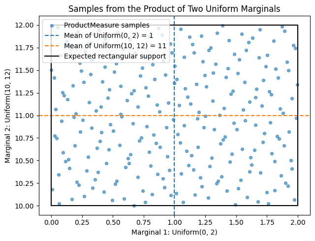

The shape, ranges, and theoretical mean checks confirm that the two-dimensional outer sampler was split into two one-dimensional blocks and transformed into the intended product of uniform marginals.

## Example 5: ProductMeasure versus SciPyWrapper

**What is being tested?** We compare two equivalent constructions for independent one-dimensional SciPy marginals.

**Expected result.** A `ProductMeasure` made from two one-dimensional `SciPyWrapper` marginals should match a single two-dimensional `SciPyWrapper` when both use outer samplers with the same seed.

**Why it matters.** This checks that ProductMeasure splitting and concatenation are mathematically equivalent to applying the same marginal transforms in one combined SciPyWrapper construction.

```python
n = 4096
seed = 55
scipy_marginals = [stats.norm(loc=0.0, scale=1.0), stats.gamma(a=2.0, scale=1.0)]
expected_means = np.array([0.0, 2.0])

product_marginals = [
    SciPyWrapper(DummySampler(1), scipy_marginals[0]),
    SciPyWrapper(DummySampler(1), scipy_marginals[1]),
]
product_measure = ProductMeasure(
    sampler=DigitalNetB2(2, seed=seed),
    marginals=product_marginals,
)
single_wrapper = SciPyWrapper(DigitalNetB2(2, seed=seed), scipy_marginals)

product_samples = product_measure(n)
scipy_samples = single_wrapper(n)
difference = product_samples - scipy_samples

product_means = product_samples.mean(axis=0)
scipy_means = scipy_samples.mean(axis=0)
product_corr = np.corrcoef(product_samples.T)[0, 1]
scipy_corr = np.corrcoef(scipy_samples.T)[0, 1]

print("ProductMeasure sample shape:", product_samples.shape)
print("SciPyWrapper sample shape:", scipy_samples.shape)
print(f"Maximum absolute difference: {np.max(np.abs(difference)):.3e}")
print(f"Mean absolute difference: {np.mean(np.abs(difference)):.3e}")
print("Arrays exactly equal:", np.array_equal(product_samples, scipy_samples))
print()
print("Metric                    ProductMeasure    SciPyWrapper    Expected")
print(f"Mean of marginal 1        {product_means[0]:>14.6f}    {scipy_means[0]:>12.6f}    {expected_means[0]:>8.6f}")
print(f"Mean of marginal 2        {product_means[1]:>14.6f}    {scipy_means[1]:>12.6f}    {expected_means[1]:>8.6f}")
print(f"Correlation               {product_corr:>14.6f}    {scipy_corr:>12.6f}    {0.0:>8.6f}")

assert product_samples.shape == scipy_samples.shape == (n, 2)
assert np.array_equal(product_samples, scipy_samples)

x_limits = (
    min(product_samples[:, 0].min(), scipy_samples[:, 0].min()),
    max(product_samples[:, 0].max(), scipy_samples[:, 0].max()),
)
y_limits = (
    min(product_samples[:, 1].min(), scipy_samples[:, 1].min()),
    max(product_samples[:, 1].max(), scipy_samples[:, 1].max()),
)

fig, axes = plt.subplots(1, 2, figsize=(11.5, 4.8), sharex=True, sharey=True)
axes[0].scatter(product_samples[:, 0], product_samples[:, 1], s=8, alpha=0.35, label="ProductMeasure")
axes[0].set_title("ProductMeasure")
axes[0].set_xlabel("Marginal 1: Normal(0, 1)")
axes[0].set_ylabel("Marginal 2: Gamma(shape=2, scale=1)")
axes[0].set_xlim(x_limits)
axes[0].set_ylim(y_limits)
axes[0].legend(loc="best")

axes[1].scatter(scipy_samples[:, 0], scipy_samples[:, 1], s=8, alpha=0.35, color="C1", label="SciPyWrapper")
axes[1].set_title("SciPyWrapper")
axes[1].set_xlabel("Marginal 1: Normal(0, 1)")
axes[1].set_ylabel("Marginal 2: Gamma(shape=2, scale=1)")
axes[1].set_xlim(x_limits)
axes[1].set_ylim(y_limits)
axes[1].legend(loc="best")

fig.suptitle("Equivalent Samples from ProductMeasure and SciPyWrapper")
plt.tight_layout()
plt.show()

fig, ax = plt.subplots(figsize=(6.5, 4.5))
ax.plot(np.abs(difference).max(axis=1), linewidth=1.5, label="Max coordinate difference per point")
ax.axhline(0.0, color="black", linestyle="--", linewidth=1.2, label="Zero difference")
ax.set_xlabel("Sample index")
ax.set_ylabel("Absolute difference")
ax.set_title("Pointwise Difference Between Equivalent Constructions")
ax.legend(loc="best")
plt.tight_layout()
plt.show()
```

n = 4096 seed = 55 scipy_marginals = [stats.norm(loc=0.0, scale=1.0), stats.gamma(a=2.0, scale=1.0)] expected_means = np.array([0.0, 2.0]) product_marginals = [ SciPyWrapper(DummySampler(1), scipy_marginals[0]), SciPyWrapper(DummySampler(1), scipy_marginals[1]), ] product_measure = ProductMeasure( sampler=DigitalNetB2(2, seed=seed), marginals=product_marginals, ) single_wrapper = SciPyWrapper(DigitalNetB2(2, seed=seed), scipy_marginals) product_samples = product_measure(n) scipy_samples = single_wrapper(n) difference = product_samples - scipy_samples product_means = product_samples.mean(axis=0) scipy_means = scipy_samples.mean(axis=0) product_corr = np.corrcoef(product_samples.T)[0, 1] scipy_corr = np.corrcoef(scipy_samples.T)[0, 1] print("ProductMeasure sample shape:", product_samples.shape) print("SciPyWrapper sample shape:", scipy_samples.shape) print(f"Maximum absolute difference: {np.max(np.abs(difference)):.3e}") print(f"Mean absolute difference: {np.mean(np.abs(difference)):.3e}") print("Arrays exactly equal:", np.array_equal(product_samples, scipy_samples)) print() print("Metric ProductMeasure SciPyWrapper Expected") print(f"Mean of marginal 1 {product_means[0]:>14.6f} {scipy_means[0]:>12.6f} {expected_means[0]:>8.6f}") print(f"Mean of marginal 2 {product_means[1]:>14.6f} {scipy_means[1]:>12.6f} {expected_means[1]:>8.6f}") print(f"Correlation {product_corr:>14.6f} {scipy_corr:>12.6f} {0.0:>8.6f}") assert product_samples.shape == scipy_samples.shape == (n, 2) assert np.array_equal(product_samples, scipy_samples) x_limits = ( min(product_samples[:, 0].min(), scipy_samples[:, 0].min()), max(product_samples[:, 0].max(), scipy_samples[:, 0].max()), ) y_limits = ( min(product_samples[:, 1].min(), scipy_samples[:, 1].min()), max(product_samples[:, 1].max(), scipy_samples[:, 1].max()), ) fig, axes = plt.subplots(1, 2, figsize=(11.5, 4.8), sharex=True, sharey=True) axes[0].scatter(product_samples[:, 0], product_samples[:, 1], s=8, alpha=0.35, label="ProductMeasure") axes[0].set_title("ProductMeasure") axes[0].set_xlabel("Marginal 1: Normal(0, 1)") axes[0].set_ylabel("Marginal 2: Gamma(shape=2, scale=1)") axes[0].set_xlim(x_limits) axes[0].set_ylim(y_limits) axes[0].legend(loc="best") axes[1].scatter(scipy_samples[:, 0], scipy_samples[:, 1], s=8, alpha=0.35, color="C1", label="SciPyWrapper") axes[1].set_title("SciPyWrapper") axes[1].set_xlabel("Marginal 1: Normal(0, 1)") axes[1].set_ylabel("Marginal 2: Gamma(shape=2, scale=1)") axes[1].set_xlim(x_limits) axes[1].set_ylim(y_limits) axes[1].legend(loc="best") fig.suptitle("Equivalent Samples from ProductMeasure and SciPyWrapper") plt.tight_layout() plt.show() fig, ax = plt.subplots(figsize=(6.5, 4.5)) ax.plot(np.abs(difference).max(axis=1), linewidth=1.5, label="Max coordinate difference per point") ax.axhline(0.0, color="black", linestyle="--", linewidth=1.2, label="Zero difference") ax.set_xlabel("Sample index") ax.set_ylabel("Absolute difference") ax.set_title("Pointwise Difference Between Equivalent Constructions") ax.legend(loc="best") plt.tight_layout() plt.show()

```
ProductMeasure sample shape: (4096, 2)
SciPyWrapper sample shape: (4096, 2)
Maximum absolute difference: 0.000e+00
Mean absolute difference: 0.000e+00
Arrays exactly equal: True

Metric                    ProductMeasure    SciPyWrapper    Expected
Mean of marginal 1             -0.000080       -0.000080    0.000000
Mean of marginal 2              1.999678        1.999678    2.000000
Correlation                     0.000040        0.000040    0.000000
```

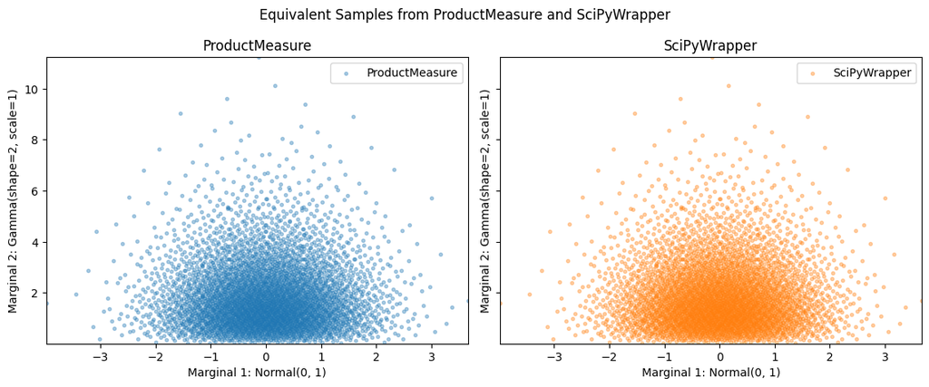

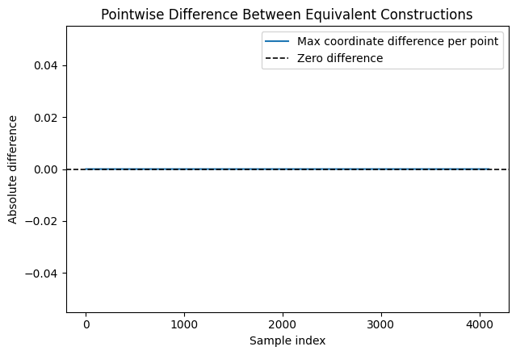

Both objects use outer samplers with the same seed, receive the same unit-cube points, and apply equivalent marginal inverse-CDF transformations. The exact array equality and zero maximum difference confirm that the ProductMeasure construction matches the combined SciPyWrapper construction here. The side-by-side plots look identical for the same reason.

## Example 6: Mixed native QMCPy and SciPyWrapper marginals

**What is being tested?** We combine one native QMCPy true measure, `Uniform(-1, 1)`, with one SciPy distribution wrapped by `SciPyWrapper`, `Beta(2, 5)`.

**Expected result.** The ProductMeasure output should have shape `(n, 2)`. The first column should be in `[-1, 1]`, and the second column should be in `[0, 1]`.

**Why it matters.** This shows that ProductMeasure can combine native QMCPy marginals and SciPy-backed marginals. A single two-dimensional outer QMC point set is split into one coordinate block for each marginal.

```python
n = 512
native_marginal = Uniform(DummySampler(1), lower_bound=-1.0, upper_bound=1.0)
scipy_beta_marginal = SciPyWrapper(DummySampler(1), stats.beta(a=2.0, b=5.0))
marginals = [native_marginal, scipy_beta_marginal]
outer_sampler = DigitalNetB2(2, seed=131)
product_measure = ProductMeasure(sampler=outer_sampler, marginals=marginals)

samples = product_measure(n)
native_block = samples[:, : native_marginal.d]
beta_block = samples[:, native_marginal.d :]

print("Native QMCPy marginal: Uniform(-1, 1)")
print("SciPyWrapper marginal: scipy.stats.beta(a=2, b=5)")
print("Expected sample shape:", (n, 2))
print("Actual sample shape:", samples.shape)
print("Native block columns: [0]")
print("SciPy beta block columns: [1]")
print(f"Native block observed range: [{native_block.min():.6f}, {native_block.max():.6f}]")
print(f"Beta block observed range: [{beta_block.min():.6f}, {beta_block.max():.6f}]")
print(f"Beta theoretical mean: {2.0 / (2.0 + 5.0):.6f}")
print(f"Beta observed mean: {beta_block.mean():.6f}")

assert samples.shape == (n, 2)
assert np.all((-1.0 <= native_block) & (native_block <= 1.0))
assert np.all((0.0 <= beta_block) & (beta_block <= 1.0))

fig, ax = plt.subplots(figsize=(6.5, 4.8))
ax.scatter(
    native_block[:, 0],
    beta_block[:, 0],
    s=12,
    alpha=0.45,
    label="ProductMeasure samples",
)
ax.set_xlabel(
    "Native QMCPy marginal: Uniform(-1, 1)",
    color="tab:red",
)
ax.set_ylabel(
    "SciPyWrapper marginal: Beta(2, 5)",
    color="tab:orange",
)
ax.tick_params(axis="x", colors="tab:red")
ax.tick_params(axis="y", colors="tab:orange")
ax.set_title("Mixed Native QMCPy and SciPyWrapper Marginals")
ax.legend(loc="best")
plt.tight_layout()
plt.show()
```

n = 512 native_marginal = Uniform(DummySampler(1), lower_bound=-1.0, upper_bound=1.0) scipy_beta_marginal = SciPyWrapper(DummySampler(1), stats.beta(a=2.0, b=5.0)) marginals = [native_marginal, scipy_beta_marginal] outer_sampler = DigitalNetB2(2, seed=131) product_measure = ProductMeasure(sampler=outer_sampler, marginals=marginals) samples = product_measure(n) native_block = samples[:, : native_marginal.d] beta_block = samples[:, native_marginal.d :] print("Native QMCPy marginal: Uniform(-1, 1)") print("SciPyWrapper marginal: scipy.stats.beta(a=2, b=5)") print("Expected sample shape:", (n, 2)) print("Actual sample shape:", samples.shape) print("Native block columns: [0]") print("SciPy beta block columns: [1]") print(f"Native block observed range: [{native_block.min():.6f}, {native_block.max():.6f}]") print(f"Beta block observed range: [{beta_block.min():.6f}, {beta_block.max():.6f}]") print(f"Beta theoretical mean: {2.0 / (2.0 + 5.0):.6f}") print(f"Beta observed mean: {beta_block.mean():.6f}") assert samples.shape == (n, 2) assert np.all((-1.0 <= native_block) & (native_block <= 1.0)) assert np.all((0.0 <= beta_block) & (beta_block <= 1.0)) fig, ax = plt.subplots(figsize=(6.5, 4.8)) ax.scatter( native_block[:, 0], beta_block[:, 0], s=12, alpha=0.45, label="ProductMeasure samples", ) ax.set_xlabel( "Native QMCPy marginal: Uniform(-1, 1)", color="tab:red", ) ax.set_ylabel( "SciPyWrapper marginal: Beta(2, 5)", color="tab:orange", ) ax.tick_params(axis="x", colors="tab:red") ax.tick_params(axis="y", colors="tab:orange") ax.set_title("Mixed Native QMCPy and SciPyWrapper Marginals") ax.legend(loc="best") plt.tight_layout() plt.show()

```
Native QMCPy marginal: Uniform(-1, 1)
SciPyWrapper marginal: scipy.stats.beta(a=2, b=5)
Expected sample shape: (512, 2)
Actual sample shape: (512, 2)
Native block columns: [0]
SciPy beta block columns: [1]
Native block observed range: [-0.997088, 0.999352]
Beta block observed range: [0.002317, 0.812349]
Beta theoretical mean: 0.285714
Beta observed mean: 0.285707
```

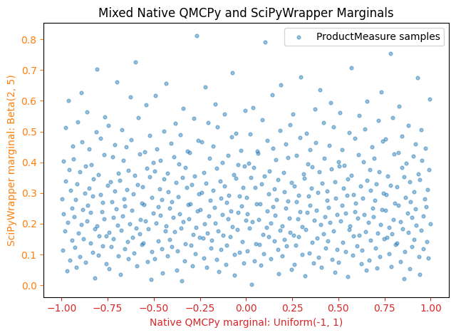

Each plotted point is one `ProductMeasure` sample. The x-coordinate is produced by the native QMCPy true measure, and the y-coordinate is produced by the `SciPyWrapper` true measure. The different axis colors distinguish the two marginals. Each scatter point represents one joint ProductMeasure sample.

The output shape and support checks confirm that ProductMeasure split the outer two-dimensional unit-cube samples into two one-dimensional blocks, applied the native QMCPy transform to the first block, and applied the SciPy beta inverse CDF through `SciPyWrapper` to the second block.

## Example 7: Zero-inflated and SciPyWrapper marginals

**What is being tested?** We combine a one-dimensional `ZeroInflatedExpUniform` marginal with a one-dimensional SciPy Gamma distribution wrapped by `SciPyWrapper`.

**Expected result.** The `ProductMeasure` output should have shape `(n, 2)`. The first column should contain nonnegative zero-inflated exponential samples, with about 40% equal to zero. The second column should contain nonnegative Gamma samples with theoretical mean 6.

**Why it matters.** This shows that `ProductMeasure` can combine a mixed distribution containing a point mass at zero with a continuous SciPy-backed marginal.

```python
p_zero = 0.4
lam = 1.5

zero_inflated_marginal = ZeroInflatedExpUniform(
    DummySampler(1),
    p_zero=p_zero,
    lam=lam,
)

gamma_shape = 3.0
gamma_scale = 2.0

gamma_marginal = SciPyWrapper(
    DummySampler(1),
    stats.gamma(a=gamma_shape, scale=gamma_scale),
)

zero_gamma_measure = ProductMeasure(
    sampler=DigitalNetB2(2, seed=17),
    marginals=[
        zero_inflated_marginal,
        gamma_marginal,
    ],
)

n = 4096
zero_gamma_samples = zero_gamma_measure(n)

zero_samples = zero_gamma_samples[:, 0]
gamma_samples = zero_gamma_samples[:, 1]

observed_zero_rate = np.mean(zero_samples == 0)
expected_gamma_mean = gamma_shape * gamma_scale
observed_gamma_mean = np.mean(gamma_samples)

print("First marginal: ZeroInflatedExpUniform(p_zero=0.4, lam=1.5)")
print("Second marginal: scipy.stats.gamma(a=3, scale=2)")
print("Expected sample shape:", (n, 2))
print("Actual sample shape:", zero_gamma_samples.shape)
print("Zero-inflated block columns: [0]")
print("SciPy Gamma block columns: [1]")
print(f"Zero-inflated observed range: [{zero_samples.min():.6f}, {zero_samples.max():.6f}]")
print(f"Expected zero proportion: {p_zero:.6f}")
print(f"Observed zero proportion: {observed_zero_rate:.6f}")
print(f"Gamma observed range: [{gamma_samples.min():.6f}, {gamma_samples.max():.6f}]")
print(f"Gamma theoretical mean: {expected_gamma_mean:.6f}")
print(f"Gamma observed mean: {observed_gamma_mean:.6f}")

assert zero_gamma_samples.shape == (n, 2)
assert np.all(np.isfinite(zero_gamma_samples))
assert np.all(zero_samples >= 0)
assert np.all(gamma_samples >= 0)
assert abs(observed_zero_rate - p_zero) < 0.03
assert abs(observed_gamma_mean - expected_gamma_mean) < 0.25

fig, ax = plt.subplots(figsize=(6.5, 4.8))
ax.scatter(
    zero_samples,
    gamma_samples,
    s=12,
    alpha=0.45,
)
ax.set_xlabel("ZeroInflatedExpUniform")
ax.set_ylabel("SciPyWrapper marginal: Gamma(3, scale=2)")
ax.set_title("Zero-Inflated and SciPy Gamma Marginals")
plt.tight_layout()
plt.show()
```

p_zero = 0.4 lam = 1.5 zero_inflated_marginal = ZeroInflatedExpUniform( DummySampler(1), p_zero=p_zero, lam=lam, ) gamma_shape = 3.0 gamma_scale = 2.0 gamma_marginal = SciPyWrapper( DummySampler(1), stats.gamma(a=gamma_shape, scale=gamma_scale), ) zero_gamma_measure = ProductMeasure( sampler=DigitalNetB2(2, seed=17), marginals=[ zero_inflated_marginal, gamma_marginal, ], ) n = 4096 zero_gamma_samples = zero_gamma_measure(n) zero_samples = zero_gamma_samples[:, 0] gamma_samples = zero_gamma_samples[:, 1] observed_zero_rate = np.mean(zero_samples == 0) expected_gamma_mean = gamma_shape * gamma_scale observed_gamma_mean = np.mean(gamma_samples) print("First marginal: ZeroInflatedExpUniform(p_zero=0.4, lam=1.5)") print("Second marginal: scipy.stats.gamma(a=3, scale=2)") print("Expected sample shape:", (n, 2)) print("Actual sample shape:", zero_gamma_samples.shape) print("Zero-inflated block columns: [0]") print("SciPy Gamma block columns: [1]") print(f"Zero-inflated observed range: [{zero_samples.min():.6f}, {zero_samples.max():.6f}]") print(f"Expected zero proportion: {p_zero:.6f}") print(f"Observed zero proportion: {observed_zero_rate:.6f}") print(f"Gamma observed range: [{gamma_samples.min():.6f}, {gamma_samples.max():.6f}]") print(f"Gamma theoretical mean: {expected_gamma_mean:.6f}") print(f"Gamma observed mean: {observed_gamma_mean:.6f}") assert zero_gamma_samples.shape == (n, 2) assert np.all(np.isfinite(zero_gamma_samples)) assert np.all(zero_samples >= 0) assert np.all(gamma_samples >= 0) assert abs(observed_zero_rate - p_zero) < 0.03 assert abs(observed_gamma_mean - expected_gamma_mean) < 0.25 fig, ax = plt.subplots(figsize=(6.5, 4.8)) ax.scatter( zero_samples, gamma_samples, s=12, alpha=0.45, ) ax.set_xlabel("ZeroInflatedExpUniform") ax.set_ylabel("SciPyWrapper marginal: Gamma(3, scale=2)") ax.set_title("Zero-Inflated and SciPy Gamma Marginals") plt.tight_layout() plt.show()

```
First marginal: ZeroInflatedExpUniform(p_zero=0.4, lam=1.5)
Second marginal: scipy.stats.gamma(a=3, scale=2)
Expected sample shape: (4096, 2)
Actual sample shape: (4096, 2)
Zero-inflated block columns: [0]
SciPy Gamma block columns: [1]
Zero-inflated observed range: [0.000000, 5.253083]
Expected zero proportion: 0.400000
Observed zero proportion: 0.399902
Gamma observed range: [0.136730, 27.547139]
Gamma theoretical mean: 6.000000
Gamma observed mean: 5.999679
```

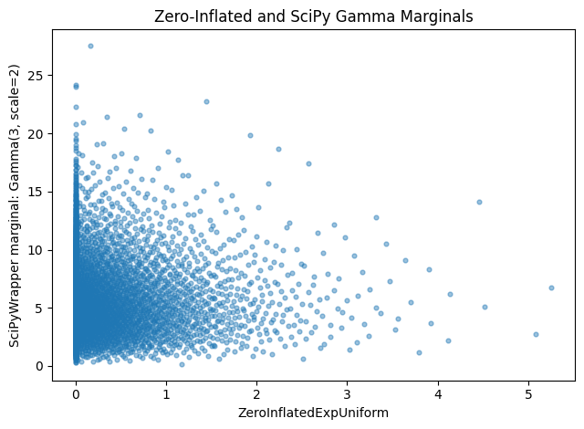

Each point is one `ProductMeasure` sample. The x-coordinate comes from the zero-inflated exponential marginal, and the y-coordinate comes from the SciPy Gamma marginal.

The actual shape `(4096, 2)` confirms that one column was produced for each marginal. The observed zero proportion is approximately `0.4`, as expected. The observed Gamma mean is approximately `6`, matching the theoretical mean `shape x scale = 3 x 2`.

The vertical group of points at `x = 0` is expected because the first marginal has a probability mass at zero.

## Example 8: Copula and SciPyWrapper marginals

**What is being tested?** We combine one two-dimensional `GaussianCopula` marginal with one one-dimensional SciPy Weibull marginal inside `ProductMeasure`. The copula uses a Normal marginal, an Exponential marginal, and a target copula correlation of `0.7`.

**Expected result.** The `ProductMeasure` output should have shape `(n, 3)`. The first two columns should form the dependent copula block. The third column should contain nonnegative Weibull samples with the expected Weibull mean.

**Why it matters.** This shows that a `ProductMeasure` marginal may itself be multidimensional and dependent. `ProductMeasure` preserves the dependence inside that block while combining it with another SciPy-backed marginal.

```python
copula_correlation = np.array(
    [
        [1.0, 0.7],
        [0.7, 1.0],
    ]
)

copula_marginal = GaussianCopula(
    sampler=DummySampler(2),
    marginals=[
        stats.norm(loc=0.0, scale=1.0),
        stats.expon(scale=1.5),
    ],
    correlation=copula_correlation,
)

weibull_shape = 1.8
weibull_scale = 2.0

weibull_marginal = SciPyWrapper(
    DummySampler(1),
    stats.weibull_min(
        c=weibull_shape,
        scale=weibull_scale,
    ),
)

copula_scipy_measure = ProductMeasure(
    sampler=DigitalNetB2(3, seed=43),
    marginals=[
        copula_marginal,
        weibull_marginal,
    ],
)

n = 4096
copula_scipy_samples = copula_scipy_measure(n)

copula_block = copula_scipy_samples[:, :2]
weibull_block = copula_scipy_samples[:, 2]

observed_correlation = np.corrcoef(
    copula_block[:, 0],
    copula_block[:, 1],
)[0, 1]

expected_weibull_mean = stats.weibull_min.mean(
    c=weibull_shape,
    scale=weibull_scale,
)
observed_weibull_mean = np.mean(weibull_block)

print("First marginal: two-dimensional GaussianCopula")
print("  Copula coordinate 1: scipy.stats.norm()")
print("  Copula coordinate 2: scipy.stats.expon(scale=1.5)")
print("  Target copula correlation: 0.7")
print("Second marginal: scipy.stats.weibull_min(c=1.8, scale=2)")
print("Expected sample shape:", (n, 3))
print("Actual sample shape:", copula_scipy_samples.shape)
print("Copula block columns: [0, 1]")
print("SciPy Weibull block columns: [2]")
print(f"Normal coordinate observed range: [{copula_block[:, 0].min():.6f}, {copula_block[:, 0].max():.6f}]")
print(f"Exponential coordinate observed range: [{copula_block[:, 1].min():.6f}, {copula_block[:, 1].max():.6f}]")
print(f"Observed copula-block Pearson correlation: {observed_correlation:.6f}")
print(f"Weibull observed range: [{weibull_block.min():.6f}, {weibull_block.max():.6f}]")
print(f"Weibull theoretical mean: {expected_weibull_mean:.6f}")
print(f"Weibull observed mean: {observed_weibull_mean:.6f}")

assert copula_scipy_samples.shape == (n, 3)
assert np.all(np.isfinite(copula_scipy_samples))
assert np.all(copula_block[:, 1] >= 0)
assert np.all(weibull_block >= 0)
assert observed_correlation > 0.3
assert abs(observed_weibull_mean - expected_weibull_mean) < 0.12

fig, ax = plt.subplots(figsize=(6.5, 4.8))
ax.scatter(
    copula_block[:, 0],
    copula_block[:, 1],
    s=12,
    alpha=0.45,
)
ax.set_xlabel("Copula coordinate 1: Normal")
ax.set_ylabel("Copula coordinate 2: Exponential")
ax.set_title("Dependent Copula Block in ProductMeasure")
plt.tight_layout()
plt.show()
```

copula_correlation = np.array( [ [1.0, 0.7], [0.7, 1.0], ] ) copula_marginal = GaussianCopula( sampler=DummySampler(2), marginals=[ stats.norm(loc=0.0, scale=1.0), stats.expon(scale=1.5), ], correlation=copula_correlation, ) weibull_shape = 1.8 weibull_scale = 2.0 weibull_marginal = SciPyWrapper( DummySampler(1), stats.weibull_min( c=weibull_shape, scale=weibull_scale, ), ) copula_scipy_measure = ProductMeasure( sampler=DigitalNetB2(3, seed=43), marginals=[ copula_marginal, weibull_marginal, ], ) n = 4096 copula_scipy_samples = copula_scipy_measure(n) copula_block = copula_scipy_samples[:, :2] weibull_block = copula_scipy_samples[:, 2] observed_correlation = np.corrcoef( copula_block[:, 0], copula_block[:, 1], )[0, 1] expected_weibull_mean = stats.weibull_min.mean( c=weibull_shape, scale=weibull_scale, ) observed_weibull_mean = np.mean(weibull_block) print("First marginal: two-dimensional GaussianCopula") print(" Copula coordinate 1: scipy.stats.norm()") print(" Copula coordinate 2: scipy.stats.expon(scale=1.5)") print(" Target copula correlation: 0.7") print("Second marginal: scipy.stats.weibull_min(c=1.8, scale=2)") print("Expected sample shape:", (n, 3)) print("Actual sample shape:", copula_scipy_samples.shape) print("Copula block columns: [0, 1]") print("SciPy Weibull block columns: [2]") print(f"Normal coordinate observed range: [{copula_block[:, 0].min():.6f}, {copula_block[:, 0].max():.6f}]") print(f"Exponential coordinate observed range: [{copula_block[:, 1].min():.6f}, {copula_block[:, 1].max():.6f}]") print(f"Observed copula-block Pearson correlation: {observed_correlation:.6f}") print(f"Weibull observed range: [{weibull_block.min():.6f}, {weibull_block.max():.6f}]") print(f"Weibull theoretical mean: {expected_weibull_mean:.6f}") print(f"Weibull observed mean: {observed_weibull_mean:.6f}") assert copula_scipy_samples.shape == (n, 3) assert np.all(np.isfinite(copula_scipy_samples)) assert np.all(copula_block[:, 1] >= 0) assert np.all(weibull_block >= 0) assert observed_correlation > 0.3 assert abs(observed_weibull_mean - expected_weibull_mean) < 0.12 fig, ax = plt.subplots(figsize=(6.5, 4.8)) ax.scatter( copula_block[:, 0], copula_block[:, 1], s=12, alpha=0.45, ) ax.set_xlabel("Copula coordinate 1: Normal") ax.set_ylabel("Copula coordinate 2: Exponential") ax.set_title("Dependent Copula Block in ProductMeasure") plt.tight_layout() plt.show()

```
First marginal: two-dimensional GaussianCopula
  Copula coordinate 1: scipy.stats.norm()
  Copula coordinate 2: scipy.stats.expon(scale=1.5)
  Target copula correlation: 0.7
Second marginal: scipy.stats.weibull_min(c=1.8, scale=2)
Expected sample shape: (4096, 3)
Actual sample shape: (4096, 3)
Copula block columns: [0, 1]
SciPy Weibull block columns: [2]
Normal coordinate observed range: [-3.598740, 3.795575]
Exponential coordinate observed range: [0.000353, 13.140296]
Observed copula-block Pearson correlation: 0.632411
Weibull observed range: [0.005352, 6.792125]
Weibull theoretical mean: 1.778573
Weibull observed mean: 1.778519
```

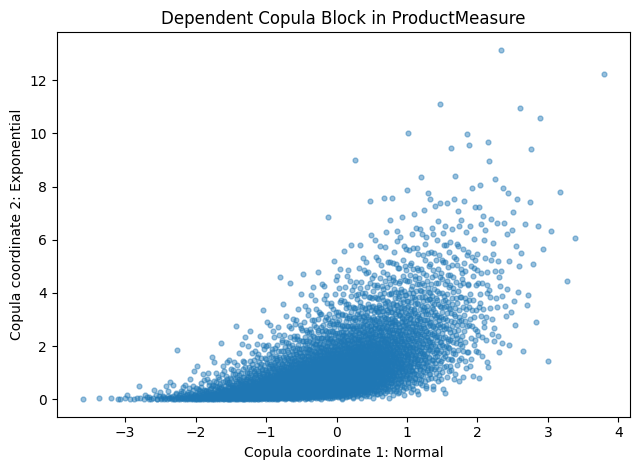

The actual shape `(4096, 3)` confirms that the two-dimensional copula block occupies columns 0 and 1, while the separate Weibull marginal occupies column 2.

The positive observed correlation between the first two columns confirms that the Gaussian copula introduced dependence inside the copula block. It is not expected to equal exactly `0.7` because the final coordinates use different Normal and Exponential marginal transformations.

The Weibull samples are nonnegative, and their observed mean is close to the theoretical Weibull mean. This confirms that `ProductMeasure` preserved the dependent two-dimensional copula block while adding the separate `SciPyWrapper` marginal.

## Example 9: Validation errors

**What is being tested?** We intentionally pass invalid inputs to `ProductMeasure`.

**Expected result.** Each invalid input should raise a clear exception before sampling starts.

**Why it matters.** These checks protect against ambiguous product measures: empty marginal lists, non-true-measure marginals, and mismatched outer sampler dimension.

```python
def show_expected_error(description, expected_exception, function):
    try:
        function()
    except expected_exception as error:
        print(f"Test: {description}")
        print(f"Exception: {type(error).__name__}")
        print(f"Message: {error}")
        print("Result: PASSED")
        print()
    else:
        raise AssertionError(f"{description}: expected {expected_exception.__name__}")

show_expected_error(
    "Empty marginal list",
    ParameterError,
    lambda: ProductMeasure(sampler=DigitalNetB2(1, seed=7), marginals=[]),
)

show_expected_error(
    "Non-AbstractTrueMeasure marginal",
    ParameterError,
    lambda: ProductMeasure(sampler=DigitalNetB2(1, seed=7), marginals=[object()]),
)

show_expected_error(
    "Outer sampler dimension does not equal sum of marginal dimensions",
    DimensionError,
    lambda: ProductMeasure(
        sampler=DigitalNetB2(2, seed=7),
        marginals=[Uniform(DummySampler(1))],
    ),
)
```

def show_expected_error(description, expected_exception, function): try: function() except expected_exception as error: print(f"Test: {description}") print(f"Exception: {type(error).__name__}") print(f"Message: {error}") print("Result: PASSED") print() else: raise AssertionError(f"{description}: expected {expected_exception.__name__}") show_expected_error( "Empty marginal list", ParameterError, lambda: ProductMeasure(sampler=DigitalNetB2(1, seed=7), marginals=[]), ) show_expected_error( "Non-AbstractTrueMeasure marginal", ParameterError, lambda: ProductMeasure(sampler=DigitalNetB2(1, seed=7), marginals=[object()]), ) show_expected_error( "Outer sampler dimension does not equal sum of marginal dimensions", DimensionError, lambda: ProductMeasure( sampler=DigitalNetB2(2, seed=7), marginals=[Uniform(DummySampler(1))], ), )

```
Test: Empty marginal list
Exception: ParameterError
Message: ProductMeasure requires a nonempty list of marginals.
Result: PASSED

Test: Non-AbstractTrueMeasure marginal
Exception: ParameterError
Message: Each ProductMeasure marginal must be an AbstractTrueMeasure instance.
Result: PASSED

Test: Outer sampler dimension does not equal sum of marginal dimensions
Exception: DimensionError
Message: ProductMeasure sampler dimension must equal the sum of marginal dimensions (2 != 1).
Result: PASSED
```

The validation errors show that ProductMeasure refuses inputs that would make the coordinate split undefined or mathematically inconsistent.

## What the examples verify

1. `DummySampler` supplies only the placeholder metadata required to construct marginals and raises an error if sampled directly.
2. The outer `ProductMeasure` sampler generates the actual unit-cube points.
3. Replicated outer samplers preserve replication dimensions.
4. One-dimensional and multidimensional marginals can be combined.
5. Zero-inflated and continuous marginals can be combined.
6. Native QMCPy and `SciPyWrapper` marginals can be combined.
7. Multidimensional dependent copula blocks can be retained inside a `ProductMeasure`.
8. Invalid configurations raise clear validation errors.
9. `AcceptanceRejection` is not currently supported as a direct marginal because it does not expose the required fixed `_transform`.

More general chained transformations for importance sampling are a separate design issue and are not addressed by `ProductMeasure`.